# Parametric Active Contours

Skip to notebook

∿Numerical Tours

← All Python tours

Download notebook[co Open in Colab](https://colab.research.google.com/github/gpeyre/numerical-tours/blob/master/python/segmentation_2_snakes_param.ipynb)

# Parametric Active Contours

Evolve a closed curve under smoothing and image-dependent forces. Track how curvature and external forces cooperate to attract the curve toward object boundaries, and inspect the role of initialization and step size.

## Run this tour

Run the cells in order with a Python 3 kernel. The first cell locates the companion data and toolbox and installs missing dependencies when needed. All worked examples include their implementation directly in this notebook. Random seeds make comparisons reproducible; you can change them to explore other samples.

```python
# Locate the companion toolbox locally, or fetch it for a standalone/Colab copy.
from pathlib import Path
import importlib.util
import os
import subprocess
import sys

working = Path.cwd()
candidates = [working, working / "python", working.parent / "python"]
python_dir = next((p for p in candidates if (p / "nt_toolbox").is_dir()), None)
if python_dir is None:
    checkout = working / "numerical-tours-support"
    if not checkout.exists():
        subprocess.run(
            [
                "git",
                "clone",
                "--depth",
                "1",
                "--branch",
                "master",
                "https://github.com/gpeyre/numerical-tours.git",
                str(checkout),
            ],
            check=True,
        )
    python_dir = checkout / "python"
os.chdir(python_dir)
if str(python_dir) not in sys.path:
    sys.path.insert(0, str(python_dir))
requirements = python_dir / "requirements.txt"
if any(
    importlib.util.find_spec(name) is None
    for name in [
        "numpy",
        "scipy",
        "matplotlib",
        "skimage",
        "sklearn",
        "pywt",
        "ipywidgets",
        "cvxpy",
        "skfmm",
        "autograd",
        "progressbar",
        "celer",
    ]
):
    subprocess.run(
        [sys.executable, "-m", "pip", "install", "-r", str(requirements)], check=True
    )

import numpy as np
import matplotlib.pyplot as plt

np.random.seed(0)
plt.rcParams.update(
    {
        "figure.figsize": (8, 4),
        "figure.dpi": 100,
        "axes.spines.top": False,
        "axes.spines.right": False,
        "font.size": 11,
        "image.cmap": "gray",
    }
)
%matplotlib inline
```

This tour explores image segmentation using parametric active contours. $\newcommand{\dotp}[2]{\langle #1, #2 \rangle}$ $\newcommand{\qandq}{\quad\text{and}\quad}$ $\newcommand{\qwhereq}{\quad\text{where}\quad}$ $\newcommand{\qifq}{ \quad \text{if} \quad }$ $\newcommand{\ZZ}{\mathbb{Z}}$ $\newcommand{\RR}{\mathbb{R}}$ $\newcommand{\CC}{\mathbb{C}}$ $\newcommand{\pa}[1]{\left(#1\right)}$ $\newcommand{\si}{\sigma}$ $\newcommand{\Nn}{\mathcal{N}}$ $\newcommand{\Bb}{\mathcal{B}}$ $\newcommand{\EE}{\mathbb{E}}$ $\newcommand{\norm}[1]{\|#1\|}$ $\newcommand{\abs}[1]{\left|#1\right|}$ $\newcommand{\choice}[1]{ \left\{ \begin{array}{l} #1 \end{array} \right. }$ $\newcommand{\al}{\alpha}$ $\newcommand{\la}{\lambda}$ $\newcommand{\ga}{\gamma}$ $\newcommand{\Ga}{\Gamma}$ $\newcommand{\La}{\Lambda}$ $\newcommand{\Si}{\Sigma}$ $\newcommand{\be}{\beta}$ $\newcommand{\de}{\delta}$ $\newcommand{\De}{\Delta}$ $\newcommand{\phi}{\varphi}$ $\newcommand{\th}{\theta}$ $\newcommand{\om}{\omega}$ $\newcommand{\Om}{\Omega}$

```python
from nt_toolbox.general import rescale
from nt_toolbox.signal import (
    bilinear_interpolate,
    gaussian_blur,
    grad,
    imageplot,
    load_image,
)
import numpy as np
import matplotlib.pyplot as plt
from numpy import (
    abs,
    arange,
    around,
    array,
    concatenate,
    cos,
    cumsum,
    equal,
    imag,
    interp,
    linspace,
    maximum,
    minimum,
    number,
    pi,
    random,
    real,
    sin,
    sqrt,
    sum,
    transpose,
    zeros,
)
from matplotlib.pyplot import axis, clf, matplotlib, plot

%matplotlib inline
```

## Parametric Curves

In this tours, the active contours are represented using parametric curve $ \ga : [0,1] \rightarrow \RR^2 $.

This curve is discretized using a piewise linear curve with $p$ segments, and is stored as a complex vector of points in the plane $\ga \in \CC^p$.

Initial polygon.

```python
gamma0 = array(
    [
        0.78,
        0.14,
        0.42,
        0.18,
        0.32,
        0.16,
        0.75,
        0.83,
        0.57,
        0.68,
        0.46,
        0.40,
        0.72,
        0.79,
        0.91,
        0.90,
    ]
) + 1j * array(
    [
        0.87,
        0.82,
        0.75,
        0.63,
        0.34,
        0.17,
        0.08,
        0.46,
        0.50,
        0.25,
        0.27,
        0.57,
        0.73,
        0.57,
        0.75,
        0.79,
    ]
)
```

Display the initial curve.

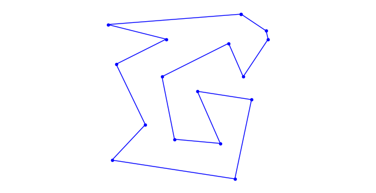

```python
periodize = lambda gamma: concatenate((gamma, [gamma[0]]))


def cplot(gamma, s="b", lw=1):
    plot(real(periodize(gamma)), imag(periodize(gamma)), s, linewidth=lw)
    axis("equal")
    axis("off")


cplot(gamma0, "b.-");
```

Number of points of the discrete curve.

```python
p = 256
```

Shortcut to re-sample a curve according to arc length.

```python
interpc = lambda x, xf, yf: interp(x, xf, real(yf)) + 1j * interp(x, xf, imag(yf))
curvabs = lambda gamma: concatenate(([0], cumsum(1e-5 + abs(gamma[:-1:] - gamma[1::]))))
resample1 = lambda gamma, d: interpc(arange(0, p) / float(p), d / d[-1], gamma)
resample = lambda gamma: resample1(periodize(gamma), curvabs(periodize(gamma)))
```

Initial curve $ \ga_1(t)$.

```python
gamma1 = resample(gamma0)
```

Display the initial curve.

[figure not shown]

```python
cplot(gamma1, "k")
```

Shortcut for forward and backward finite differences.

```python
shiftR = lambda c: concatenate(([c[-1]], c[:-1:]))
shiftL = lambda c: concatenate((c[1::], [c[0]]))
BwdDiff = lambda c: c - shiftR(c)
FwdDiff = lambda c: shiftL(c) - c
```

The tangent to the curve is computed as $$ t_\ga(s) = \frac{\ga'(t)}{\norm{\ga'(t)}} $$ and the normal is $ n_\ga(t) = t_\ga(t)^\bot. $

Shortcut to compute the tangent and the normal to a curve.

```python
normalize = lambda v: v / maximum(abs(v), 1e-10)
tangent = lambda gamma: normalize(FwdDiff(gamma))
normal = lambda gamma: -1j * tangent(gamma)
```

Move the curve in the normal direction, by computing $ \ga_1(t) \pm \delta n_{\ga_1}(t) $.

```python
delta = 0.03
gamma2 = gamma1 + delta * normal(gamma1)
gamma3 = gamma1 - delta * normal(gamma1)
```

Display the curves.

```
(np.float64(0.09818192340611909),
 np.float64(0.979037189504653),
 np.float64(0.011000256259768859),
 np.float64(0.942237845572892))
```

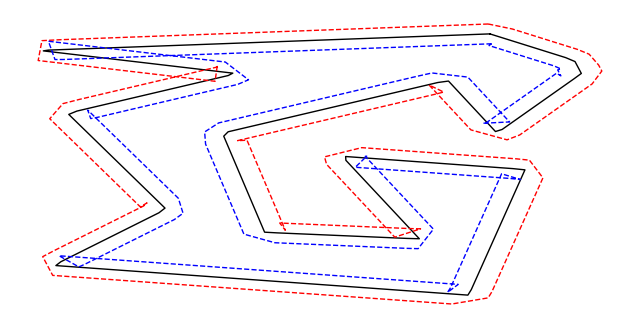

```python
cplot(gamma1, "k")
cplot(gamma2, "r--")
cplot(gamma3, "b--")
axis("tight")
axis("off")
```

## Evolution by Mean Curvature

Note that the gradient of an energy is defined with respect to the curve-dependent inner product $$ \dotp{a}{b} = \int_0^1 \dotp{a(t)}{b(t)} \norm{\ga'(t)} d t. $$ The set of curves can thus be thought as being a Riemannian surface.

The simplest evolution is the mean curvature evolution. It corresponds to minimization of the curve length $$ E(\ga) = \int_0^1 \norm{\ga'(t)} d t $$

The gradient of the length is $$ \nabla E(\ga)(t) = -\kappa_\ga(t) n_\ga(t) $$ where $ \kappa_\ga $ is the curvature, defined as $$ \kappa_\ga(t) = \frac{1}{\norm{\ga'(t)}} \dotp{ t_\ga'(t) }{ n_\ga(t) } . $$

Shortcut for normal times curvature $ \kappa_\ga(t) n_\ga(t) $.

```python
normalC = lambda gamma: BwdDiff(tangent(gamma)) / abs(FwdDiff(gamma))
```

Time step for the evolution. It should be very small because we use an explicit time stepping and the curve has strong curvature.

```python
dt = 0.001 / 100
```

Number of iterations.

```python
Tmax = 3.0 / 100
niter = round(Tmax / dt)
```

Initialize the curve for $s=0$.

```python
gamma = gamma1
```

Evolution of the curve.

```python
gamma = gamma + dt * normalC(gamma)
```

To stabilize the evolution, it is important to re-sample the curve so that it is unit-speed parametrized. You do not need to do it every time step though (to speed up).

```python
gamma = resample(gamma)
```

**Worked example 1:** Perform the curve evolution. We now resample it a few times.

[figure not shown]

```python
gamma = gamma1
displist = around(linspace(0, niter, 10))
k = 0
for i in arange(0, niter + 1):
    gamma = resample(gamma + dt * normalC(gamma))
    if i == displist[k]:
        lw = 1
        if i == 0 or i == niter:
            lw = 4
        cplot(gamma, "r", lw)
        k = k + 1
        axis("tight")
        axis("off")
```

## Geodesic Active Contours

Geodesic active contours minimize a weighted length $$ E(\ga) = \int_0^1 W(\ga(t)) \norm{\ga'(t)} d t, $$ where $W(x)>0$ is the geodesic metric, that should be small in areas where the image should be segmented.

Size of the image $n$.

```python
n = 200
```

Create a synthetic weight $W(x)$.

```python
nbumps = 40
theta = random.rand(nbumps, 1) * 2 * pi
r = 0.6 * n / 2
a = array([0.62 * n, 0.6 * n])
x = around(a[0] + r * cos(theta))
y = around(a[1] + r * sin(theta))
W = zeros([n, n])
for i in arange(0, nbumps):
    W[int(x[i].item()), int(y[i].item())] = 1
W = gaussian_blur(W, 6.0)
W = rescale(-minimum(W, 0.05), 0.3, 1)
```

Display the metric $W$.

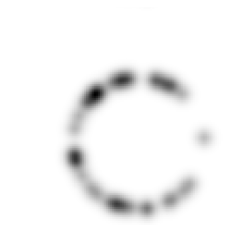

```python
imageplot(W)
```

Pre-compute the gradient $\nabla W(x)$ of the metric.

```python
G = grad(W)
G = G[:, :, 0] + 1j * G[:, :, 1]
```

Display the image of the magnitude $\norm{\nabla W(x)}$ of the gradient.

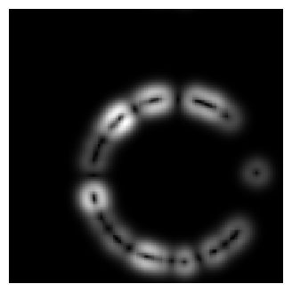

```python
imageplot(abs(G))
```

Shortcut to evaluate the gradient and the potential along a curve.

```python
EvalG = lambda gamma: bilinear_interpolate(G, imag(gamma), real(gamma))
EvalW = lambda gamma: bilinear_interpolate(W, imag(gamma), real(gamma))
```

Create a circular curve $\ga_0$.

```python
r = 0.98 * n / 2  # radius
p = 128  # number of points on the curve
theta = transpose(linspace(0, 2 * pi, p + 1))
theta = theta[0:-1]
gamma0 = n / 2 * (1 + 1j) + r * (cos(theta) + 1j * sin(theta))
```

Initialize the curve at time $t=0$ with a circle.

```python
gamma = gamma0
```

For this experiment, the time step should be larger, because the curve is in $[0,n-1] \times [0,n-1]$.

```python
dt = 1
```

Number of iterations.

```python
Tmax = 5000
niter = round(Tmax / dt)
```

Display the curve on the background.

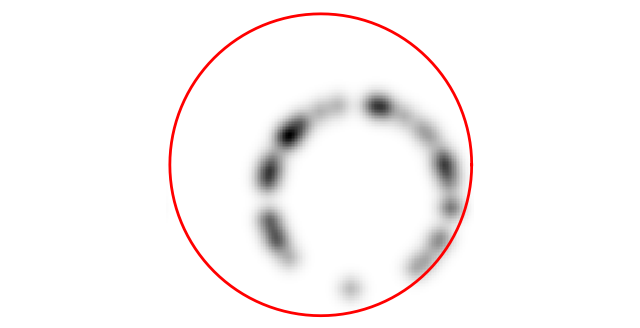

```python
lw = 2
clf
imageplot(transpose(W))
cplot(gamma, "r", lw)
```

The gradient of the energy is $$ \nabla E(\ga) = -W(\ga(t)) \kappa_\ga(t) n_\ga(t) + \dotp{\nabla W(\ga(t))}{ n_\ga(t) } n_\ga(t). $$

Pointwise innerproduct on the curve.

```python
dotp = lambda c1, c2: real(c1) * real(c2) + imag(c1) * imag(c2)
```

Evolution of the curve according to this gradient.

```python
N = normal(gamma)
g = -EvalW(gamma) * normalC(gamma) + dotp(EvalG(gamma), N) * N
gamma = gamma - dt * g
```

To avoid the curve from being poorly sampled, it is important to re-sample it evenly.

```python
gamma = resample(gamma)
```

**Worked example 2:** Perform the curve evolution.

[figure not shown]

```python
gamma = gamma0
displist = around(linspace(0, niter, 10))
k = 0
clf
imageplot(transpose(W))
for i in arange(0, niter + 1):
    N = normal(gamma)
    g = EvalW(gamma) * normalC(gamma) - dotp(EvalG(gamma), N) * N
    gamma = resample(gamma + dt * g)
    if i == displist[k]:
        lw = 1
        if i == 0 or i == niter:
            lw = 4
        cplot(gamma, "r", lw)
        k = k + 1
        axis("equal")
        axis("off")
```

## Medical Image Segmentation

One can use a gradient-based metric to perform edge detection in medical images.

Load an image $f$.

```python
n = 256
name = "nt_toolbox/data/cortex.bmp"
f = load_image(name, n)
```

Display.

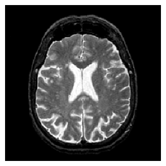

```python
imageplot(f)
```

An edge detector metric can be defined as a decreasing function of the gradient magnitude. $$ W(x) = \psi( d \star h_a(x) ) \qwhereq d(x) = \norm{\nabla f(x)}. $$ where $h_a$ is a blurring kernel of width $a>0$.

Compute the magnitude of the gradient.

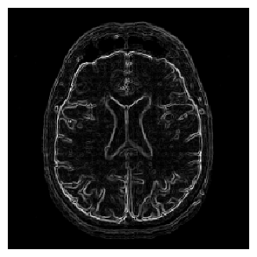

```python
G = grad(f)
d0 = sqrt(sum(G**2, 2))
imageplot(d0)
```

Blur it by $h_a$.

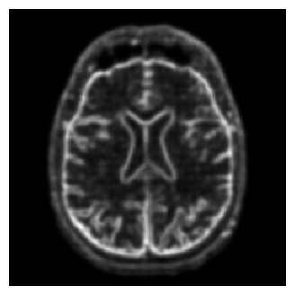

```python
a = 2
d = gaussian_blur(d0, a)
imageplot(d)
```

Compute a decreasing function of the gradient to define $W$.

```python
d = minimum(d, 0.4)
W = rescale(-d, 0.8, 1)
```

Display it.

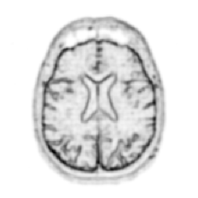

```python
imageplot(W)
```

Number of points.

```python
p = 128
```

**Worked example 3:** Create an initial circle $\gamma_0$ of $p$ points. When plotting the image, you need to transpose it to have axis coherent with the cplot.

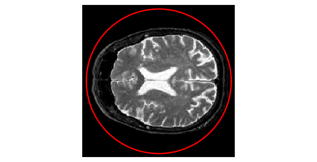

```python
r = 0.95 * n / 2
p = 128  # number of points on the curve
theta = transpose(linspace(0, 2 * pi, p + 1))
theta = theta[0:-1]
gamma0 = n / 2 * (1 + 1j) + r * (cos(theta) + 1j * sin(theta))
gamma = gamma0
clf
imageplot(transpose(f))
cplot(gamma, "r", 2)
```

Step size.

```python
dt = 2
```

Number of iterations.

```python
Tmax = 9000
niter = round(Tmax / dt)
```

**Worked example 4:** Perform the curve evolution.

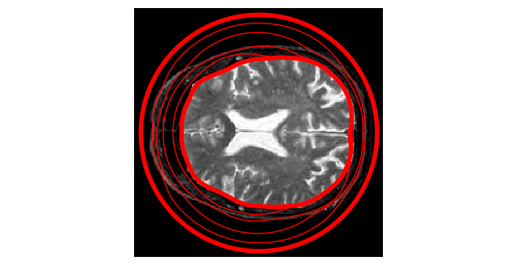

```python
G = grad(W)
G = G[:, :, 0] + 1j * G[:, :, 1]
EvalG = lambda gamma: bilinear_interpolate(G, imag(gamma), real(gamma))
EvalW = lambda gamma: bilinear_interpolate(W, imag(gamma), real(gamma))
#
gamma = gamma0
displist = around(linspace(0, niter, 10))
k = 0
clf
imageplot(transpose(f))
for i in arange(0, niter + 1):
    n = normal(gamma)
    g = EvalW(gamma) * normalC(gamma) - dotp(EvalG(gamma), n) * n
    gamma = resample(gamma + dt * g)
    if i == displist[k]:
        lw = 1
        if i == 0 or i == niter:
            lw = 4
        cplot(gamma, "r", lw)
        k = k + 1
        axis("equal")
        axis("off")
```

## Evolution of a Non-closed Curve

It is possible to perform the evolution of a non-closed curve by adding boundary constraint $$ \ga(0)=x_0 \qandq \ga(1)=x_1. $$

In this case, the algorithm find a local minimizer of the geodesic distance between the two points.

Note that a much more efficient way to solve this problem is to use the Fast Marching algorithm to find the global minimizer of the geodesic length.

Load an image $f$.

```python
n = 256
f = load_image(name, n)
f = f[45:105, 60:120]
n = f.shape[0]
```

Display.

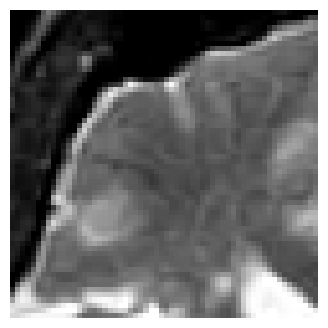

```python
imageplot(f)
```

**Worked example 5:** Compute an edge attracting criterion $W(x)>0$, that is small in area of strong gradient.

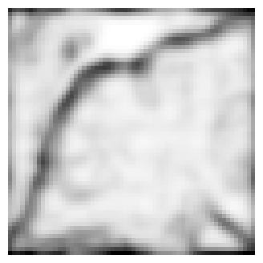

```python
G = grad(f)
G = sqrt(sum(G**2, 2))
sigma = 1.5
G = gaussian_blur(G, sigma)
G = minimum(G, 0.4)
W = rescale(-G, 0.4, 1)
clf
imageplot(W)
```

Start and end points $x_0$ and $x_1$.

```python
x0 = 4 + 55j
x1 = 53 + 4j
```

Initial curve $\ga_0$.

```python
p = 128
t = transpose(linspace(0, 1, p))
gamma0 = t * x1 + (1 - t) * x0
```

Initialize the evolution.

```python
gamma = gamma0
```

Display.

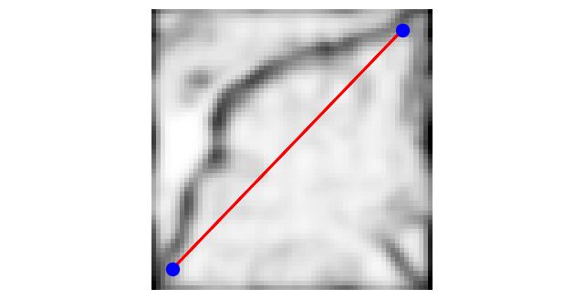

```python
clf
imageplot(transpose(W))
cplot(gamma, "r", 2)
plot(real(gamma[0]), imag(gamma[0]), "b.", markersize=20)
plot(real(gamma[-1]), imag(gamma[-1]), "b.", markersize=20);
```

Re-sampling for non-periodic curves.

```python
curvabs = lambda gamma: concatenate(([0], cumsum(1e-5 + abs(gamma[:-1:] - gamma[1::]))))
resample1 = lambda gamma, d: interpc(arange(0, p) / float(p - 1), d / d[-1], gamma)
resample = lambda gamma: resample1(gamma, curvabs(gamma))
```

Time step.

```python
dt = 1 / 10
```

Number of iterations.

```python
Tmax = 2000 * 4 / 7
niter = round(Tmax / dt)
```

**Worked example 6:** Perform the curve evolution. Be careful to impose the boundary conditions at each step.

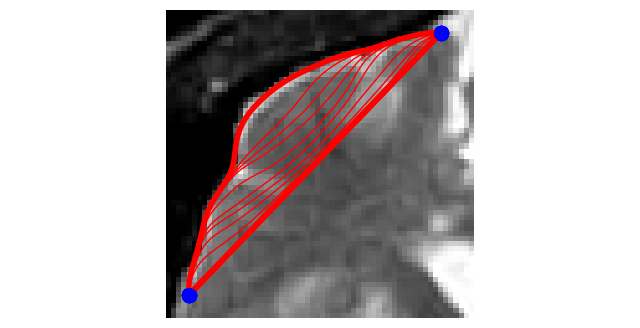

```python
G = grad(W)
G = G[:, :, 0] + 1j * G[:, :, 1]
EvalG = lambda gamma: bilinear_interpolate(G, imag(gamma), real(gamma))
EvalW = lambda gamma: bilinear_interpolate(W, imag(gamma), real(gamma))
#
gamma = gamma0
displist = around(linspace(0, niter, 10))
k = 0
clf
imageplot(transpose(f))
for i in arange(0, niter + 1):
    N = normal(gamma)
    g = EvalW(gamma) * normalC(gamma) - dotp(EvalG(gamma), N) * N
    gamma = gamma + dt * g
    gamma = resample(gamma)
    # impose start/end point
    gamma[0] = x0
    gamma[-1] = x1
    if i == displist[k]:
        lw = 1
        if i == 0 or i == niter:
            lw = 4
        cplot(gamma, "r", lw)
        k = k + 1
        axis("equal")
        axis("off")
        plot(real(gamma[0]), imag(gamma[0]), "b.", markersize=20)
        plot(real(gamma[-1]), imag(gamma[-1]), "b.", markersize=20)
```

## References and further reading

- John Canny. [A Computational Approach to Edge Detection](https://doi.org/10.1109/TPAMI.1986.4767851). 1986, IEEE Transactions on Pattern Analysis and Machine Intelligence 8(6), 679–698. Detection, localization, and nonmaximum suppression of edges.
- Michael Kass, Andrew Witkin, and Demetri Terzopoulos. [Snakes: Active Contour Models](https://doi.org/10.1007/BF00133570). 1988, International Journal of Computer Vision 1, 321–331. Parametric curves driven by regularization and image forces.
- Stanley Osher and James A. Sethian. Fronts Propagating with Curvature-Dependent Speed: Algorithms Based on Hamilton–Jacobi Formulations. 1988, Journal of Computational Physics 79(1), 12–49. Implicit front propagation using level-set functions.
- Tony F. Chan and Luminita A. Vese. [Active Contours Without Edges](https://doi.org/10.1109/83.902291). 2001, IEEE Transactions on Image Processing 10(2), 266–277. Region-based segmentation when image gradients are weak.
- Gabriel Peyré. [Advanced Signal, Image and Surface Processing](https://www.numerical-tours.com/book/AdvancedSignalProcessing.pdf). 2010, course notes. A mathematical companion to the Numerical Tours.

**On this page**